# mass_spec

## Accessing Mahdi Mass Spectrum Data using Python

pyOpenMS is an open-source Python library for mass spectrometry, specifically for the analysis of proteomics and metabolomics data in Python https://pyopenms.readthedocs.io/en/latest/index.html

scipy.signal is a very robust set of signal processing tools, of which one is scipy.signal.find_peaks https://docs.scipy.org/doc/scipy/reference/generated/scipy.signal.find_peaks.html

```python
import pyopenms as oms #
```

```python
from scipy.signal import find_peaks
```

```python
import matplotlib.pyplot as plt
from pyopenms.plotting import plot_spectrum
import matplotlib.pyplot as plt
```

Define a simple function to read in a mxXML file as produced by Mahdi and return peaks. (Later we will write another function which can read a Mahdi text file containing only peaks.)

```python
def read_ms_mxXML(file):
    exp = oms.MSExperiment()
    oms.MzXMLFile().load(file, exp)
    return exp.getSpectrum(0).get_peaks() # Spectrum::([mz], [intensity])
```

Read in the Mahdi mzXML file for Recipe C

```python
peaks = read_ms_mxXML("2024_01_11_Recipe_C_pH_7.3_K2SO3_950_MeNH2HCl_2024_min_20_0_J8_1.mzXML")
```

`peaks` is a a tuple comprised of two numpy arrays, the first of which is `mz` and the second is `intensity`

```python
peaks
```

```
(array([1400.0300293 , 1400.04309082, 1400.05615234, ..., 1719.99609375,
        1720.01062012, 1720.02502441]),
 array([49., 86., 89., ..., 82., 79., 92.], dtype=float32))
```

We will likely want to access these as seperate arrays

```python
mz, intensity = peaks
```

```python
mz
```

```
array([1400.0300293 , 1400.04309082, 1400.05615234, ..., 1719.99609375,
       1720.01062012, 1720.02502441])
```

We can work with this directly, but it is long . . .

```python
len(peaks[0])
```

```
23250
```

First, let's see if we can re-create a Mahdi type plot using a function built into pyOpenMS. It requires that we first create a MSSpectrum object and set the `peaks` to it. (There may be a more direct way of doing this.)

```python
spectrum = oms.MSSpectrum()
spectrum.set_peaks(sp)
```

```python
spectrum
```

```
<pyopenms._pyopenms_6.MSSpectrum at 0x7fe9d5a1a250>
```

Looks like we can get the peaks back fairly easily ...

```python
spectrum.get_peaks()
```

```
(array([1400.0300293 , 1400.04309082, 1400.05615234, ..., 1719.99609375,
        1720.01062012, 1720.02502441]),
 array([49., 86., 89., ..., 82., 79., 92.], dtype=float32))
```

Here is the `pyOpenMS` plot function

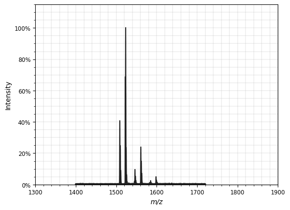

```python
plot_spectrum(spectrum)
plt.show()
```

Too spread out, but it appears that `plot_spectrum` plays well with `matplotlib`

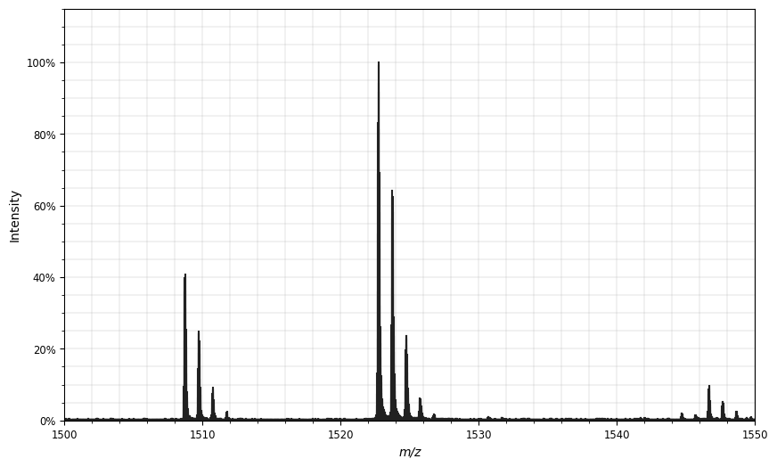

```python
plt.figure(figsize=(10, 6))
plot_spectrum(spectrum)
plt.xlim(1500, 1550)
plt.show()
```

ChatGPT to the rescue. Looks like this plot can also done in pure `matplotlab`. Quicker too

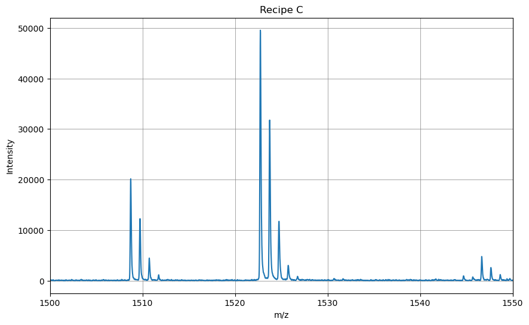

```python
plt.figure(figsize=(10, 6))
mz, intensity = spectrum.get_peaks()
plt.plot(mz, intensity)
plt.grid(color='gray', linestyle='-', linewidth=0.5)
plt.xlabel("m/z")
plt.ylabel("Intensity")
plt.title('Recipe C')
plt.xlim(1500, 1550)
plt.show()
```

Turns out peak labeling is hard as each peak can actually be comprised of many small peaks as `mz` values are long floats. Accordingly, the top 10 peaks are all clustered around 1522.

Let's try out the peak calling function `scipy.signal.find_peaks` It takes the intensity array and returns an index of positions with the largest peaks. (It also returns a dict containing information about the peaks returned.)

```python
# Pick peaks with minimum heights
peak_idx = find_peaks(intensity, height=1500)[0]
len(peak_idx)
```

```
13
```

Now use peak_idx to get the corresponding values for `mz` and `intensity`

```python
mz_lg = mz[peak_idx]
intensity_lg = intensity[peak_idx]
```

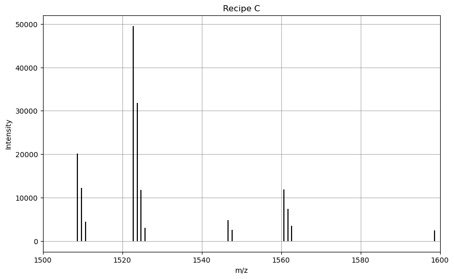

```python
plt.figure(figsize=(10, 6))
plt.vlines(mz_lg, ymin=0, ymax=intensity_lg, color='black')
plt.grid(color='gray', linestyle='-', linewidth=0.5)
plt.xlabel("m/z")
plt.ylabel("Intensity")
plt.title('Recipe C')
plt.xlim(1500, 1600)
plt.show()
```

It would be nice to be able to group these clusters of peaks. In general, clustering can be a hard problem, but here, we know that the members in each group should be no more than 5 or 6 apart from each other.

I started writting code, but realized that someone had already solved this problem. This function is **not** mine.

```python
def group_by_distance(arr, dist):
    # Sort the array along with their original indices
    sorted_arr_with_indices = sorted(enumerate(arr), key=lambda x: x[1])

    # Initialize the first group
    groups = [[sorted_arr_with_indices[0][0]]]

    # Iterate and group elements
    for idx, element in sorted_arr_with_indices[1:]:
        # Check if the element is close enough to the last element of the last group
        if element - arr[groups[-1][-1]] <= dist:
            groups[-1].append(idx)
        else:
            # Start a new group
            groups.append([idx])

    return groups
```

```python
lg_idx = group_by_distance(mz_lg, 5) # 5 is a heuristic guess
lg_idx
```

```
[[0, 1, 2], [3, 4, 5, 6], [7, 8], [9, 10, 11], [12]]
```

That looks pretty good! Each of the groups corresponds to a cluster of peaks. This way we can compare the max of two groups and begin to quantify things like efficiency.

We can also pick out the principal member of a group and use it to measure distance between the principal member of other groups. We can potentially weed out K and Na signals and flag unwanted side products.

We can look at the relative heights of the peaks within a grouping to see if there are problems.

Here is the plot again

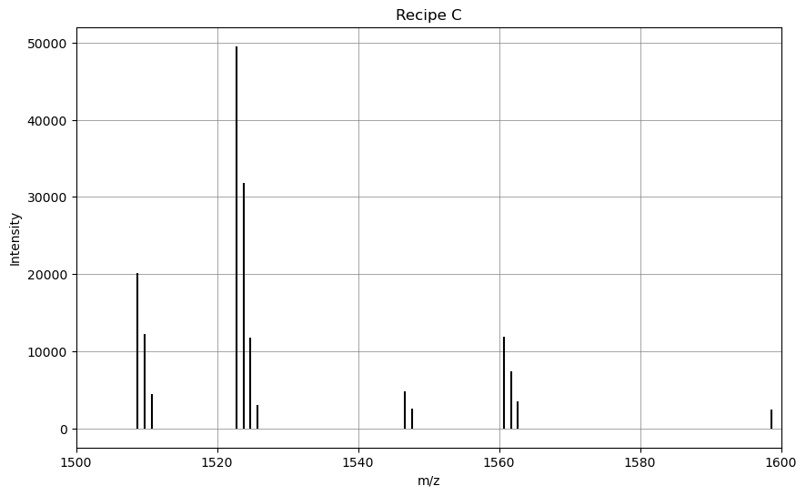

```python
plt.figure(figsize=(10, 6))
plt.vlines(mz_lg, ymin=0, ymax=intensity_lg, color='black')
plt.grid(color='gray', linestyle='-', linewidth=0.5)
plt.xlabel("m/z")
plt.ylabel("Intensity")
plt.title('Recipe C')
plt.xlim(1500, 1600)
plt.show()
```

```python
# Rem: This is the index of of peaks called by `find_peaks`
peak_idx
```

```
array([ 8171,  8245,  8319,  9202,  9276,  9350,  9423, 10952, 11024,
       11970, 12043, 12116, 14704])
```

```python
# Rem: This is the group index which indexed into peak_idx. So, [0,1,2] indexes [8171,8245,8319]
lg_idx
```

```
[[0, 1, 2], [3, 4, 5, 6], [7, 8], [9, 10, 11], [12]]
```

```python
# This combines the two indexes together
group_idx = [peak_idx[g_idx] for g_idx in lg_idx]
group_idx
```

```
[array([8171, 8245, 8319]),
 array([9202, 9276, 9350, 9423]),
 array([10952, 11024]),
 array([11970, 12043, 12116]),
 array([14704])]
```

Finally, we can do something. Here we can find the distance between the principal peaks of the first groups

```python
mz[group_idx[1]][0] -  mz[group_idx[0]][0]
```

```
14.00537109375
```

We should clean this up with a function

```python
def cluster_dist(group1, group2, idx=group_idx):
    group1, group2 = group1 - 1 , group2 - 1 # Python is 0-based
    return round(abs(mz[group_idx[group1]][0] -  mz[group_idx[group2]][0]),2)
```

```python
cluster_dist(1,2)
```

```
14.01
```

```python
cluster_dist(1,3)
```

```
37.93
```

```python
cluster_dist(2,3)
```

```
23.92
```

```python
cluster_dist(2,4)
```

```
37.92
```

```python
cluster_dist(1,4)
```

```
51.93
```

```python
cluster_dist(1,5)
```

```
89.84
```

It's late but some of those distances look quite right. Perhaps find_peak is doing some averaging.

One last thing, lets determine the efficiency of the C->4mC. Though we can look at it, we can now calculate it.

```python
# Only defined for first two groups
def C_4mC_efficiency():
    return round(intensity[group_idx[0]][0] / intensity[group_idx[1]][0],2)
```

```python
C_4mC_efficiency()
```

```
0.41
```

That's it for tonight. This was an exploration. This is all very brittle. This notebook needs to be generalized to be used to interactively report out results. Alternatively, it needs to be converted into a python package with a higer level of functions to allow terminal exploration of Mahdi results